# Assignment 2

## *Does a job training program improve the earnings of disadvantaged workers?*

```python
# Silent warnings
import warnings
warnings.filterwarnings("ignore")

# Core
import numpy as np
import scipy
import statsmodels.api as sm
import statsmodels.formula.api as smf
import pylab

# Data
import pandas as pd
from sklearn import tree
from sklearn import metrics
from sklearn import neighbors
from sklearn import ensemble


# Visualisation
import matplotlib.pyplot as plt
import seaborn as sns

%matplotlib inline
sns.set_style('darkgrid')
plt.style.use('ggplot')
```

## Introduction

**Business Context.** In the 1980s, Robert Lalonde conducted a study to evaluate the effects of training programs on labour workers. He observed the characteristic background data of the individuals involved. Several of them were selected for enrollment in the job training program (the National Supported Work Demonstration). The training program specifically targeted unemployed women, ex-drug addicts, ex-criminal offenders, and high school dropouts.

[figure not shown]

The Department of Labor is interested in digging deeper into this data and coming up with some actionable insights in order to raise the earnings of disadvantaged workers. They have contracted you as a data science consultant to assist them with this task.

**Business Problem.** Your goal is to evaluate **whether the job training program *causes* the earnings of disadvantaged workers to go up**.

**Analytical Context.** In this case we will continue our discussion of causal inference. We will study the importance of covariate balance and explore how to perform matching to get this balance. We will leverage a lot of the new classification models we have learned for this purpose.

## Examining the data

The Lalonde dataset provides information on annual income for workers who enroll in the training workshop and those who did not enroll in the year subsequent to training. The outcome of interest is `re78` in which we want to know if there was an increase in earnings in 1978:

1. **age**: age in years
2. **educ**: years of schooling
3. **black**: indicator variable for blacks
4. **hisp**: indicator variable for Hispanics
5. **married**: indicator variable for martial status
6. **nodegr**: indicator variable for high school diploma
7. **re74**: real earnings in 1974
8. **re75**: real earnings in 1975
9. **re78**: real earnings in 1978 - this is the outcome of interest
10. **treat**: an indicator variable for treatment status

```python
lalonde_df = pd.read_csv('lalonde.csv', index_col=0)
lalonde_df.head()
```

|  | treat | age | educ | black | hispan | married | nodegree | re74 | re75 | re78 |
| --- | --- | --- | --- | --- | --- | --- | --- | --- | --- | --- |
| NSW1 | 1 | 37 | 11 | 1 | 0 | 1 | 1 | 0.0 | 0.0 | 9930.0460 |
| NSW2 | 1 | 22 | 9 | 0 | 1 | 0 | 1 | 0.0 | 0.0 | 3595.8940 |
| NSW3 | 1 | 30 | 12 | 1 | 0 | 0 | 0 | 0.0 | 0.0 | 24909.4500 |
| NSW4 | 1 | 27 | 11 | 1 | 0 | 0 | 1 | 0.0 | 0.0 | 7506.1460 |
| NSW5 | 1 | 33 | 8 | 1 | 0 | 0 | 1 | 0.0 | 0.0 | 289.7899 |

### Exercise 1:

#### 1.1

Provide summary statistics for all the variables in the dataset. What can you say about the average income of the population throughout the years? What percentage of the population saw a decrease in income from 1974 to 1975? What do you think happened in 1975?

**Answer.**

```python
# Display summary statistics
summary_stats = lalonde_df.describe()
print(summary_stats)

# Calculate average income for each year
average_income_1974 = lalonde_df['re74'].mean()
average_income_1975 = lalonde_df['re75'].mean()
average_income_1978 = lalonde_df['re78'].mean()
print("\nAverage income in 1974:", average_income_1974)
print("Average income in 1975:", average_income_1975)
print("Average income in 1978:", average_income_1978)

# Calculate percentage of population with a decrease in income from 1974 to 1975
decrease_count = np.sum(lalonde_df['re75'] < lalonde_df['re74'])
total_count = len(lalonde_df)
percentage_decrease = (decrease_count / total_count) * 100
print("\nPercentage of population with a decrease in income from 1974 to 1975:", percentage_decrease, "%")
```

```
            treat         age        educ       black      hispan     married  \
count  614.000000  614.000000  614.000000  614.000000  614.000000  614.000000
mean     0.301303   27.363192   10.268730    0.395765    0.117264    0.415309
std      0.459198    9.881187    2.628325    0.489413    0.321997    0.493177
min      0.000000   16.000000    0.000000    0.000000    0.000000    0.000000
25%      0.000000   20.000000    9.000000    0.000000    0.000000    0.000000
50%      0.000000   25.000000   11.000000    0.000000    0.000000    0.000000
75%      1.000000   32.000000   12.000000    1.000000    0.000000    1.000000
max      1.000000   55.000000   18.000000    1.000000    1.000000    1.000000

         nodegree          re74          re75          re78
count  614.000000    614.000000    614.000000    614.000000
mean     0.630293   4557.546569   2184.938207   6792.834483
std      0.483119   6477.964479   3295.679043   7470.730792
min      0.000000      0.000000      0.000000      0.000000
25%      0.000000      0.000000      0.000000    238.283425
50%      1.000000   1042.330000    601.548400   4759.018500
75%      1.000000   7888.498250   3248.987500  10893.592500
max      1.000000  35040.070000  25142.240000  60307.930000

Average income in 1974: 4557.546569446256
Average income in 1975: 2184.9382070846914
Average income in 1978: 6792.834482980456

Percentage of population with a decrease in income from 1974 to 1975: 46.416938110749186 %
```

**Economic Recession**: The mid-1970s saw economic downturns in many countries, including the United States and the United Kingdom. These recessions led to layoffs, reduced working hours, and stagnation in wages, ultimately resulting in decreased income for many individuals and families.

#### 1.2

What percentage of the workers in our dataset are in the treatment group? Find the difference in means and medians of earnings between the control group and the treatment group. Is the difference of means statistically significant?

**Note:** Remember that the *treatment and control groups* correspond to the sets of workers that were enrolled and not enrolled in the job training program, respectively. We can check if a worker is part of the treatment group by simply checking the value of the `treat` column.

**Answer.**

```python
from scipy.stats import ttest_ind

# Calculate the percentage of workers in the treatment group
treatment_percentage = (lalonde_df['treat'].sum() / len(lalonde_df)) * 100
print("Percentage of workers in the treatment group:", treatment_percentage)

# Create separate dataframes for treatment and control groups
treatment_group = lalonde_df[lalonde_df['treat'] == 1]
control_group = lalonde_df[lalonde_df['treat'] == 0]

# Calculate the difference in means and medians of earnings between the two groups
difference_mean = treatment_group['re78'].mean() - control_group['re78'].mean()
difference_median = treatment_group['re78'].median() - control_group['re78'].median()
print("\nDifference in means of earnings between treatment and control groups:", difference_mean)
print("Difference in medians of earnings between treatment and control groups:", difference_median)

# Perform a t-test to determine if the difference in means is statistically significant
t_stat, p_value = ttest_ind(treatment_group['re78'], control_group['re78'])
print("\nT-statistic:", t_stat)
print("P-value:", p_value)
if p_value < 0.05:
    print("The difference in means is not statistically significant (p < 0.05).")
else:
    print("The difference in means is statistically significant (p >= 0.05).")
```

[output not shown]

#### 1.3

Does your previous result mean that the treatment had a negative impact? Why or why not?

**Answer.**

The difference in means between the treatment and control groups is -635.03, indicating that, on average, the treatment group had lower earnings in 1978 compared to the control group. However, the p-value associated with the t-test is 0.334, which is greater than the typical significance level of 0.05. This means that there is not enough evidence to reject the null hypothesis that there is a difference in earnings between the treatment and control groups.

There appears to be also class imbalance, only 30 % of the population underwent treatment while the rest were control groups. If the balance was close to 50-50 then we could make a more accurate statement regarding the performance of the treatment

## Assessing balance between the control group and the treatment group

Suppose we want to assess whether balance has been achieved for a particular feature $x = age$. That is, we would like to check whether the treatment and control groups have similar distributions of ages. We can look at **Standardized Mean Differences (SMD)**, which is calculated as follows: let $(\bar{x}_t,s_t^2)$ and $(\bar{x}_c, s_c^2)$ denote the mean and variance corresponding to the treatment and control groups of the particular feature of interest. Then, the SMD is defined as the value:

$$\mathrm{SMD}(x)=\frac{\bar{x}_{t}-{\bar{x}_{c}}}{\sqrt{\frac{s^{2}_{t} + s^{2}_{c}}{2}}}.$$

We can calculate the SMD for every feature. If our calculated SMD is 1, then that means there is a 1 standard deviation difference in means. The benefit of having standard deviation in the denominator is that this number becomes insensitive to the scale of the feature.

After computing this measurement for all of our features, there is a rule of thumb that is commonly used to determine whether that feature is balanced or not (similar to the idea of using 0.05 as a threshold for $p$ - values):

1. **SMD < 0.1**: We say that the feature is balanced. In general, for a **randomized trial**, the SMD for all of the covariates should typically fall into this bucket.
2. **SMD is between 0.1 and 0.2**: Not necessarily balanced, but small enough that people are usually not too worried about them. Sometimes, even after performing matching, there might still be a few covariates whose SMD falls in this range.
3. **SMD > 0.2**: Values that are greater than this threshold are considered seriously imbalanced.

### Exercise 2:

#### 2.1

Assess covariate balance between the treatment and control groups. What features (covariates) are imbalanced between the control group and the treatment group in this dataset?

**Answer.**

```python
# Calculate SMD for each feature
features = ['age', 'educ', 're74', 're75', 're78']
smd_dict = {}
for feature in features:
    xbar_t = treatment_group[feature].mean()
    xbar_c = control_group[feature].mean()
    s2_t = treatment_group[feature].var()
    s2_c = control_group[feature].var()
    smd = (xbar_t - xbar_c) / np.sqrt((s2_t + s2_c) / 2)
    smd_dict[feature] = smd

# Print SMD for each feature
print("Standardized Mean Differences (SMD):")
for feature, smd in smd_dict.items():
    print(f"{feature}: {smd}")

# Assess balance based on SMD thresholds
imbalanced_features = [feature for feature, smd in smd_dict.items() if abs(smd) > 0.2]
print("\nImbalanced features:")
print(imbalanced_features)
```

```
Standardized Mean Differences (SMD):
age: -0.24190362292609974
educ: 0.04475508511087092
re74: -0.5957515910049516
re75: -0.2870021087425335
re78: -0.08370809386395342

Imbalanced features:
['age', 're74', 're75']
```

#### 2.2

Make plots which show the histograms for both the treatment and control groups of the imbalanced covariates.

**Answer.**

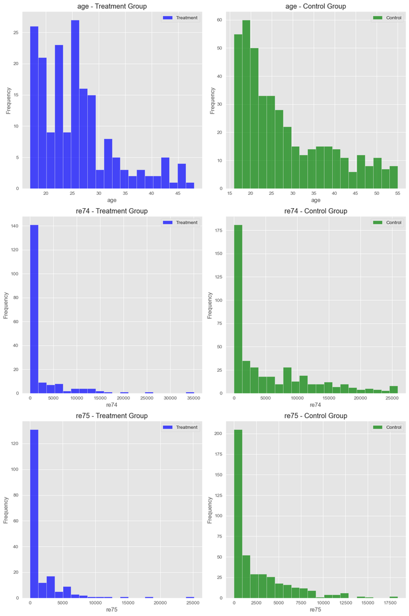

```python
# Create subplots for each imbalanced feature
fig, axes = plt.subplots(nrows=len(imbalanced_features), ncols=2, figsize=(12, 6 * len(imbalanced_features)))

# Plot histograms for treatment and control groups
for i, feature in enumerate(imbalanced_features):
    ax1 = axes[i][0]  # Subplot for treatment group
    ax2 = axes[i][1]  # Subplot for control group

    # Plot histogram for treatment group
    ax1.hist(treatment_group[feature], bins=20, color='blue', alpha=0.7, label='Treatment')
    ax1.set_title(f"{feature} - Treatment Group")
    ax1.set_xlabel(feature)
    ax1.set_ylabel("Frequency")
    ax1.legend()

    # Plot histogram for control group
    ax2.hist(control_group[feature], bins=20, color='green', alpha=0.7, label='Control')
    ax2.set_title(f"{feature} - Control Group")
    ax2.set_xlabel(feature)
    ax2.set_ylabel("Frequency")
    ax2.legend()

plt.tight_layout()
plt.show()
```

## Propensity score matching using logistic regression

In order to balance the covariates of the control and treatment groups, we will use **matching**. Remember that we used matching in Case 7.5 to balance a population of prisoners to evaluate the effectiveness of a program aiming to reduce recidivism. Thus, the situation here is quite similar.

In Case 7.5 we used the *Euclidean distance* on the sample data to create the matching: for each individual of the treatment group, we would find the closest (in Euclidean distance) individual in the control group to match on. Although this method is attractive in general, we may have instances in which the balancing of some particular feature is more important than others. Say the employment program was aiming to create a positive impact within the Hispanic community and a higher proportion of individuals in the treatment group were Hispanic. The Euclidean distance would not take this into account, and we may end up comparing the effect of the treatment between Hispanics and other ethnicities.

We can alleviate this issue by using a metric that takes into account the characteristics of the treatment group. In this context, a metric called the **propensity score** helps us do the matching on select features in an efficient way. The key idea is that *the features that are correlated with the probability of a worker being selected into the treatment group affect our causal results*. A propensity score is this probability. The propensity score for subject $i$, denoted as $\pi_i$ is defined as:

$\pi_i$ = P(Subject $i$ is given training given their features $X_i$)

As an example, if a person had a propensity score of 0.3, that would mean that given their particular covariates, there was a 30% chance that they were placed in the treatment group. We can calculate this score by fitting a classification model to our data, where the input features are our covariates, and the output is whether that person was part of the treatment group or not.

### Exercise 3:

#### 3.1

Estimate the propensity scores using a logistic regression. Build a logistic regression model where the outcome variable is whether a subject was in the treatment group or not, and the covariates are all the other variables except `re78`. How would you interpret the predicted values output by the model?

**Answer.**

```python
# Fit a logistic regression model to the data predicting the treatment variable from the covariates
logistic_model = smf.logit('treat ~ age + educ + black + hispan+ married + nodegree+ re74 + re75', data=lalonde_df).fit()
```

```
Optimization terminated successfully.
         Current function value: 0.397267
         Iterations 7
```

#### 3.2

Use `.predict()` to obtain the propensity scores of individuals in our dataset. Save the the results with the name `pscore_logit` (these will be used later). In addition, make plots which show the distribution for both the treatment and control groups of propensity scores.

**Answer.**

```python
# Propensity scores of individuals in the dataset
pscore_logit = logistic_model.predict()
```

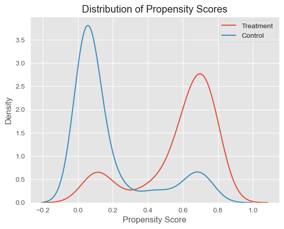

```python
# Add the propensity scores to the dataframe
lalonde_df['pscore_logit'] = pscore_logit

# Plot the distribution of the propensity scores for the treatment and control groups
sns.kdeplot(lalonde_df[lalonde_df['treat'] == 1]['pscore_logit'], label='Treatment')
sns.kdeplot(lalonde_df[lalonde_df['treat'] == 0]['pscore_logit'], label='Control')
plt.title('Distribution of Propensity Scores')
plt.xlabel('Propensity Score')
plt.ylabel('Density')
plt.legend()
```

```python
lalonde_df.head()
```

|  | treat | age | educ | black | hispan | married | nodegree | re74 | re75 | re78 | pscore_logit |
| --- | --- | --- | --- | --- | --- | --- | --- | --- | --- | --- | --- |
| NSW1 | 1 | 37 | 11 | 1 | 0 | 1 | 1 | 0.0 | 0.0 | 9930.0460 | 0.638770 |
| NSW2 | 1 | 22 | 9 | 0 | 1 | 0 | 1 | 0.0 | 0.0 | 3595.8940 | 0.224634 |
| NSW3 | 1 | 30 | 12 | 1 | 0 | 0 | 0 | 0.0 | 0.0 | 24909.4500 | 0.678244 |
| NSW4 | 1 | 27 | 11 | 1 | 0 | 0 | 1 | 0.0 | 0.0 | 7506.1460 | 0.776324 |
| NSW5 | 1 | 33 | 8 | 1 | 0 | 0 | 1 | 0.0 | 0.0 | 289.7899 | 0.701639 |

```python
lalonde_df.head()
```

|  | treat | age | educ | black | hispan | married | nodegree | re74 | re75 | re78 | pscore_logit |
| --- | --- | --- | --- | --- | --- | --- | --- | --- | --- | --- | --- |
| NSW1 | 1 | 37 | 11 | 1 | 0 | 1 | 1 | 0.0 | 0.0 | 9930.0460 | 0.638770 |
| NSW2 | 1 | 22 | 9 | 0 | 1 | 0 | 1 | 0.0 | 0.0 | 3595.8940 | 0.224634 |
| NSW3 | 1 | 30 | 12 | 1 | 0 | 0 | 0 | 0.0 | 0.0 | 24909.4500 | 0.678244 |
| NSW4 | 1 | 27 | 11 | 1 | 0 | 0 | 1 | 0.0 | 0.0 | 7506.1460 | 0.776324 |
| NSW5 | 1 | 33 | 8 | 1 | 0 | 0 | 1 | 0.0 | 0.0 | 289.7899 | 0.701639 |

### Matching using $k$-nearest neighbors

We are going to match each treated subject with a control subject using nearest neighbors matching on the estimated propensity score. Here, we use another popular clustering algorithm: the **$k$-nearest neighbors ($k$-NN) algorithm**. This algorithm is quite similar to the one we used in Case 7.5. However, instead of finding the single control individual with the closest propensity score, it finds the $k$ control individuals with the closest propensity scores. The use of $k>1$ is handy for classification purposes: if each individual lies in a category, we can classify a new individual by finding its $k$ nearest neighbors and use the most common category of its neighbors as the selected category for the new individual.

### Exercise 4 :

In this exercise, we will use the `sklearn.neighbors` function [`NearestNeighbors`](https://scikit-learn.org/stable/modules/generated/sklearn.neighbors.NearestNeighbors.html#sklearn.neighbors.NearestNeighbors.kneighbors) to find, for each subject in the treatment group, the $k=5$ subjects in the control group with the closest propensity scores.

#### 4.1

Separate the propensity scores `pscore_logit` found in Exercise 3 for treatment and control groups. Call these `treat_pscores` and `control_pscores` respectively. Use the `control_pscores` to train a $k$-NN algorithm with $k=5$.

**Hint:** Load the model using `knn = neighbors.NearestNeighbors(n_neighbors=5,metric='euclidean')`. You may want to reshape the control scores using `control_pscores.reshape(-1,1)`.

**Answer.**

```python
from sklearn.neighbors import NearestNeighbors

# Seperate the pscores for the treatment and control groups
treat_pscores = lalonde_df[lalonde_df['treat'] == 1]['pscore_logit']
control_pscores = lalonde_df[lalonde_df['treat'] == 0]['pscore_logit']

# Initialize k-NN algorithm with k=5
knn = NearestNeighbors(n_neighbors=5, metric='euclidean')

# Train the k-NN algorithm using control_pscores
knn.fit(control_pscores.values.reshape(-1,1))
```

```
NearestNeighbors(metric='euclidean')
```

#### 4.2

Find the indices of the five nearest neighbors using the method `.kneighbors()` applied to `treat_pscores`.

**Answer.**

```python
# Use knn to find indices of five nearest neighbors for each treated subject
distances, indices = knn.kneighbors(treat_pscores.values.reshape(-1, 1), n_neighbors=5)

# Print the indices of the five nearest neighbors
print("Indices of the five nearest neighbors for each treated subject:")
print(indices)
```

```
Indices of the five nearest neighbors for each treated subject:
[[ 68 386 372 385 375]
 [110  65 338 149 198]
 [369 188 267 380 354]
 [225 195 117 387 411]
 [139 133 276 217 371]
 [217 139 371 415 325]
 [255  14 233 367 351]
 [117 225 195 387 411]
 [225 117 195 387 411]
 [343 108  91 177 293]
 [268 172 325 415 265]
 [380 267 354 188 252]
 [367 351 255 397 375]
 [216 290  47 332 227]
```

[output cut: 171 more lines]

#### 4.3

Match the treatment and control groups using the closest of the five neighbors found above. Your output should be a pair of `DataFrames`, each with $185$ rows from the `lalonde_df`. The first should correspond to the treatment group and the second should correspond to the matched control group.

**Answer.**

```python
# Get the indices of the five nearest neighbors for each treatment group individual
indices = knn.kneighbors(treat_pscores.values.reshape(-1, 1), return_distance=False)

# Create dataframe treatment
treatment_pscores_df = lalonde_df.loc[treat_pscores.index]

print(treatment_pscores_df.shape)

# Create matched control dataframe
matched_control_df = lalonde_df[lalonde_df['treat']==0].iloc[indices[:,0],:]
print(matched_control_df.shape)
```

```
(185, 11)
(185, 11)
```

### Propensity score distribution plot after matching

Let's take a glance at the distribution of propensity score after matching. Both groups have similar distributions on the propensity score. This means we have reach a balance in both groups. This enables us to further analyze the causality effect of the treatment.

### Exercise 5 :

Make a plot which shows the histograms of propensity scores for the control and treatment groups after matching. Compare your results with the plot in Exercise 3.2.

**Answer.**

```python
matched_control_df.head()
```

|  | treat | age | educ | black | hispan | married | nodegree | re74 | re75 | re78 | pscore_logit |
| --- | --- | --- | --- | --- | --- | --- | --- | --- | --- | --- | --- |
| PSID69 | 0 | 30 | 17 | 1 | 0 | 0 | 0 | 17827.37000 | 5546.4190 | 14421.1300 | 0.638554 |
| PSID111 | 0 | 51 | 11 | 0 | 0 | 0 | 1 | 48.98167 | 3813.3870 | 1525.0140 | 0.224079 |
| PSID370 | 0 | 16 | 9 | 1 | 0 | 0 | 1 | 0.00000 | 0.0000 | 2158.9590 | 0.678789 |
| PSID226 | 0 | 39 | 10 | 1 | 0 | 0 | 1 | 844.44400 | 889.7903 | 701.9201 | 0.778912 |
| PSID140 | 0 | 19 | 9 | 1 | 0 | 0 | 1 | 1079.55600 | 2873.4680 | 14344.2900 | 0.705085 |

```python
treatment_pscores_df.head()
```

|  | treat | age | educ | black | hispan | married | nodegree | re74 | re75 | re78 | pscore_logit |
| --- | --- | --- | --- | --- | --- | --- | --- | --- | --- | --- | --- |
| NSW1 | 1 | 37 | 11 | 1 | 0 | 1 | 1 | 0.0 | 0.0 | 9930.0460 | 0.638770 |
| NSW2 | 1 | 22 | 9 | 0 | 1 | 0 | 1 | 0.0 | 0.0 | 3595.8940 | 0.224634 |
| NSW3 | 1 | 30 | 12 | 1 | 0 | 0 | 0 | 0.0 | 0.0 | 24909.4500 | 0.678244 |
| NSW4 | 1 | 27 | 11 | 1 | 0 | 0 | 1 | 0.0 | 0.0 | 7506.1460 | 0.776324 |
| NSW5 | 1 | 33 | 8 | 1 | 0 | 0 | 1 | 0.0 | 0.0 | 289.7899 | 0.701639 |

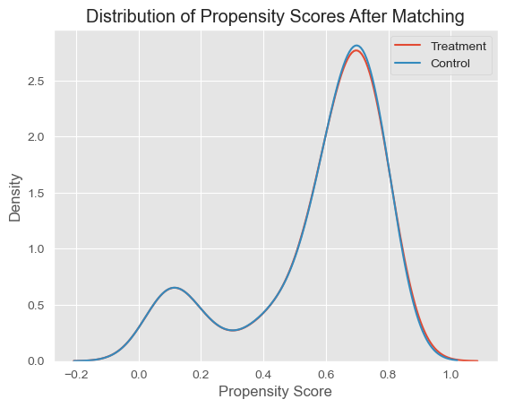

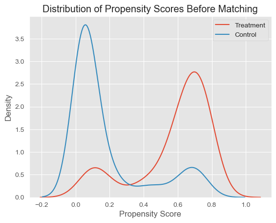

```python
# Reset index of matched_control_df
matched_control_df = matched_control_df.reset_index(drop=True)

# Plot the distribution of propensity scores after matching
sns.kdeplot(treatment_pscores_df['pscore_logit'], label='Treatment')
sns.kdeplot(matched_control_df['pscore_logit'], label='Control')
plt.title('Distribution of Propensity Scores After Matching')
plt.xlabel('Propensity Score')
plt.ylabel('Density')
plt.legend()
plt.show()

# Add the propensity scores to the dataframe
lalonde_df['pscore_logit'] = pscore_logit

# Plot the distribution of the propensity scores for the treatment and control groups
sns.kdeplot(lalonde_df[lalonde_df['treat'] == 1]['pscore_logit'], label='Treatment')
sns.kdeplot(lalonde_df[lalonde_df['treat'] == 0]['pscore_logit'], label='Control')
plt.title('Distribution of Propensity Scores Before Matching')
plt.xlabel('Propensity Score')
plt.ylabel('Density')
plt.legend()
plt.show()
```

### Exercise 6 :

Assess covariate balance after the $k$-NN matching. For this, compute the absolute standardized differences in means in the covariates after matching, $$ASMD_a(x)=\frac{\bar{x}_{t,a}-{\bar{x}_{c,a}}}{\sqrt{\frac{s^{2}_{t,b} + s^{2}_{c,b}}{2}}},$$ where $\bar{x}_{t,a}$ and $\bar{x}_{c,a}$ are, respectively, the means of covariate $x$ in the treatment and control groups after matching, and $s^{2}_{t,b}$ and $s^{2}_{c,b}$ are, correspondingly, the sample variances treatment and control groups before matching.

One reason to use the sample variances before matching rather than the sample variances after matching is to free the comparisons of the means after matching from simultaneous changes in the variances. Comment on covariate balance.

**Answer.**

```python
# Compute mean and variance of each covariate for treatment and control groups after matching
means_treatment_matched = treatment_pscores_df.drop(columns=['treat', 'pscore_logit', 'black', 'hispan', 'married', 'nodegree']).mean()
means_control_matched = matched_control_df.drop(columns=['treat', 'pscore_logit', 'black', 'hispan', 'married', 'nodegree']).mean()
variances_treatment_before = treatment_pscores_df.drop(columns=['treat', 'pscore_logit', 'black', 'hispan', 'married', 'nodegree']).var()
variances_control_before = matched_control_df.drop(columns=['treat', 'pscore_logit', 'black', 'hispan', 'married', 'nodegree']).var()

# Compute absolute standardized differences in means for each covariate
ASMDs = abs(means_treatment_matched - means_control_matched) / ((variances_treatment_before + variances_control_before)/2)**0.5

# Print absolute standardized differences in means for each covariate
print("Absolute Standardized Differences in Means (ASMDs) after matching:")
print(ASMDs)
```

```
Absolute Standardized Differences in Means (ASMDs) after matching:
age     0.203580
educ    0.013873
re74    0.049934
re75    0.010219
re78    0.265653
dtype: float64
```

### Exercise 7 :

Estimate the average effect of treatment on wages (`re78`) after matching. What do you conclude?

**Answer.**

```python
# Calculate the average effect of treatment on wages (re78) after matching
average_effect = treatment_pscores_df['re78'].mean() - matched_control_df['re78'].mean()

# Print the average effect of treatment on wages
print("Average effect of treatment on wages after matching:", average_effect)
```

```
Average effect of treatment on wages after matching: 1810.2862518918919
```

The results are positive, and it suggests that the treatment led to a increase in wages

## Propensity score matching using decision trees and random forests

### Exercise 8 :

To validate our propensity score calculations, let's try calculating them using other models such as decision trees and random forests.

#### 8.1

Build a decision tree regressor where the outcome variable is whether a subject was in the treatment group or not, and the covariates are all the other variables except `re78`. Use the `sklearn.tree` function `DecisionTreeRegressor(max_depth=4)` and call the new propensity scores `pscore_tree`.

**Answer.**

```python
lalonde_df.head()
```

|  | treat | age | educ | black | hispan | married | nodegree | re74 | re75 | re78 | pscore_logit |
| --- | --- | --- | --- | --- | --- | --- | --- | --- | --- | --- | --- |
| NSW1 | 1 | 37 | 11 | 1 | 0 | 1 | 1 | 0.0 | 0.0 | 9930.0460 | 0.638770 |
| NSW2 | 1 | 22 | 9 | 0 | 1 | 0 | 1 | 0.0 | 0.0 | 3595.8940 | 0.224634 |
| NSW3 | 1 | 30 | 12 | 1 | 0 | 0 | 0 | 0.0 | 0.0 | 24909.4500 | 0.678244 |
| NSW4 | 1 | 27 | 11 | 1 | 0 | 0 | 1 | 0.0 | 0.0 | 7506.1460 | 0.776324 |
| NSW5 | 1 | 33 | 8 | 1 | 0 | 0 | 1 | 0.0 | 0.0 | 289.7899 | 0.701639 |

```python
from sklearn.tree import DecisionTreeRegressor

# Separate predictors (covariates) and outcome variable
X_tree = lalonde_df.drop(columns=['treat', 're78', 'pscore_logit'])  # Exclude 'treat' and 're78' from predictors
y_tree = lalonde_df['treat']  # Outcome variable

# Create decision tree regressor
tree_regressor = DecisionTreeRegressor(max_depth=4)

# Fit decision tree regressor
tree_regressor.fit(X_tree, y_tree)

# Predict probabilities of being in the treatment group
pscore_tree = tree_regressor.predict(X_tree)

# Save the propensity scores
lalonde_df['pscore_tree'] = pscore_tree
```

```python
lalonde_df.head()
```

|  | treat | age | educ | black | hispan | married | nodegree | re74 | re75 | re78 | pscore_logit | pscore_tree |
| --- | --- | --- | --- | --- | --- | --- | --- | --- | --- | --- | --- | --- |
| NSW1 | 1 | 37 | 11 | 1 | 0 | 1 | 1 | 0.0 | 0.0 | 9930.0460 | 0.638770 | 0.864583 |
| NSW2 | 1 | 22 | 9 | 0 | 1 | 0 | 1 | 0.0 | 0.0 | 3595.8940 | 0.224634 | 0.500000 |
| NSW3 | 1 | 30 | 12 | 1 | 0 | 0 | 0 | 0.0 | 0.0 | 24909.4500 | 0.678244 | 0.864583 |
| NSW4 | 1 | 27 | 11 | 1 | 0 | 0 | 1 | 0.0 | 0.0 | 7506.1460 | 0.776324 | 0.864583 |
| NSW5 | 1 | 33 | 8 | 1 | 0 | 0 | 1 | 0.0 | 0.0 | 289.7899 | 0.701639 | 0.864583 |

#### 8.2

Plot the decision tree regressor using the code

```
fig = plt.gcf()
fig.set_size_inches(150, 100)
tree.plot_tree(dt,filled=True,feature_names=cleaned_df.columns)
fig.savefig('tree.png')
```

Replace `dt` with the name of the model created in Exercise 8.1. Use the plot to estimate the probability that a 24 year old, single, uneducated Hispanic individual that earned $\$20000$ in 1974 was enrolled in the employment program. Do the same with a black man with the same characteristics. (Assume that there were no black Hispanics in the study.)

**Answer.**

```python
# Plot the decision tree regressor
fig = plt.gcf()
fig.set_size_inches(150, 100)
tree.plot_tree(tree_regressor, filled=True, feature_names=X_tree.columns)
plt.savefig('tree.png')

# Define the characteristics of the individuals
individual1 = [[24, 0, 0, 1, 0, 1, 20000, 0]]  # 24-year-old, single, uneducated Hispanic individual earning $20000 in 1974
individual2 = [[24, 0, 1, 0, 0, 1, 20000, 0]]  # 24-year-old, single, uneducated Black individual earning $20000 in 1974

# Predict the probability of enrollment for each individual using the decision tree regressor
probability_individual1 = tree_regressor.predict(individual1)[0]
probability_individual2 = tree_regressor.predict(individual2)[0]

print("Probability of enrollment for the Hispanic individual:", probability_individual1)
print("Probability of enrollment for the Black individual:", probability_individual2)
```

```
Probability of enrollment for the Hispanic individual: 0.0
Probability of enrollment for the Black individual: 0.5945945945945946
```

[figure not shown]

#### 8.3

Estimate the propensity scores now by using random forests. For the model, use the `sklearn.ensemble` function `RandomForestClassifier` with parameters `n_estimators=100, max_depth=4, random_state=42`. Then, use the method `predict_proba` to extract the propensity scores. Name the scores `pscore_forest`.

**Answer.**

```python
lalonde_df.head()
```

[output not shown]

```python
from sklearn.ensemble import RandomForestClassifier

# Create a Random Forest Classifier model
forest_classifier = RandomForestClassifier(n_estimators=100, max_depth=4, random_state=42)


# Fit the model to the data
X_forest = lalonde_df.drop(columns=['treat', 're78', 'pscore_logit', 'pscore_tree'])
y_forest = lalonde_df['treat']  # Outcome variable
forest_classifier.fit(X_forest, y_forest)

# Extract the propensity scores using predict_proba
pscore_forest = forest_classifier.predict_proba(X_forest)[:, 1]

# Print the propensity scores
print("Propensity scores using Random Forest Classifier:")
print(pscore_forest)
```

[output not shown]

[output cut: 49 more lines]

[output not shown]

#### 8.4

Make a plot with the three ROC curves corresponding to the logistic regression, decision tree, and random forest classifiers used to compute the propensity scores. What is the AUC of each model? Which model *seems* to do the best job?

**Answer.**

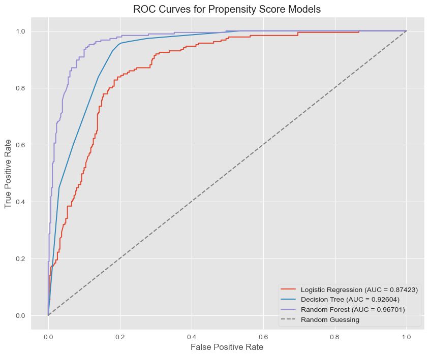

```python
from sklearn.metrics import roc_curve, roc_auc_score
y = lalonde_df['treat']
# Compute ROC curves and AUC for each model
fpr_logit, tpr_logit, _ = roc_curve(y, pscore_logit)
auc_logit = roc_auc_score(y, pscore_logit)

fpr_tree, tpr_tree, _ = roc_curve(y, pscore_tree)
auc_tree = roc_auc_score(y, pscore_tree)

fpr_forest, tpr_forest, _ = roc_curve(y, pscore_forest)
auc_forest = roc_auc_score(y, pscore_forest)

# Plot ROC curves
plt.figure(figsize=(10, 8))
plt.plot(fpr_logit, tpr_logit, label=f'Logistic Regression (AUC = {auc_logit:.5f})')
plt.plot(fpr_tree, tpr_tree, label=f'Decision Tree (AUC = {auc_tree:.5f})')
plt.plot(fpr_forest, tpr_forest, label=f'Random Forest (AUC = {auc_forest:.5f})')

# Plot ROC curve for random guessing (no skill)
plt.plot([0, 1], [0, 1], linestyle='--', color='gray', label='Random Guessing')

# Set labels and title
plt.xlabel('False Positive Rate')
plt.ylabel('True Positive Rate')
plt.title('ROC Curves for Propensity Score Models')
plt.legend()
plt.grid(True)
plt.show()
```

We can see that the random forest algorithm performs the best by looking at the AUC and the ROC curves respectively. The decision trees function similarily which is expected.

#### 8.5

Consider the following statement:

> "*A model with a higher AUC provides much better estimates of the true propensity scores. In particular, a matching using the propensity scores of such a model will balance the covariates much better.*"

Is the statement true or false? Explain.

**Answer.**

#### 8.6

Repeat the matching procedure now with the estimated propensity scores `pscore_tree` and `pscore_forest`. Assess the covariate balances and estimate the average effect of treatment on wages (`re78`) after matching. Compare your results.

**Answer.**

```python
# Save the propensity scores
lalonde_df['pscore_forest'] = pscore_forest
lalonde_df.head()
```

|  | treat | age | educ | black | hispan | married | nodegree | re74 | re75 | re78 | pscore_logit | pscore_tree | pscore_forest |
| --- | --- | --- | --- | --- | --- | --- | --- | --- | --- | --- | --- | --- | --- |
| NSW1 | 1 | 37 | 11 | 1 | 0 | 1 | 1 | 0.0 | 0.0 | 9930.0460 | 0.638770 | 0.864583 | 0.714104 |
| NSW2 | 1 | 22 | 9 | 0 | 1 | 0 | 1 | 0.0 | 0.0 | 3595.8940 | 0.224634 | 0.500000 | 0.693720 |
| NSW3 | 1 | 30 | 12 | 1 | 0 | 0 | 0 | 0.0 | 0.0 | 24909.4500 | 0.678244 | 0.864583 | 0.868177 |
| NSW4 | 1 | 27 | 11 | 1 | 0 | 0 | 1 | 0.0 | 0.0 | 7506.1460 | 0.776324 | 0.864583 | 0.876391 |
| NSW5 | 1 | 33 | 8 | 1 | 0 | 0 | 1 | 0.0 | 0.0 | 289.7899 | 0.701639 | 0.864583 | 0.870301 |

```python
# Seperate the pscores for the treatment and control groups
treat_pscore_tree = lalonde_df[lalonde_df['treat'] == 1]['pscore_tree']
control_pscore_tree = lalonde_df[lalonde_df['treat'] == 0]['pscore_tree']

treat_pscore_forest = lalonde_df[lalonde_df['treat'] == 1]['pscore_forest']
control_pscore_forest = lalonde_df[lalonde_df['treat'] == 0]['pscore_forest']

# Initialize k-NN algorithm with k=5
knn_tree = NearestNeighbors(n_neighbors=5, metric='euclidean')
knn_forest = NearestNeighbors(n_neighbors=5, metric='euclidean')

# Train the k-NN algorithm using control_pscores
knn_tree.fit(control_pscore_tree.values.reshape(-1,1))
knn_forest.fit(control_pscore_forest.values.reshape(-1,1))
```

```
NearestNeighbors(metric='euclidean')
```

```python
# Use knn to find indices of five nearest neighbors for each treated subject
distances_tree, indices_tree = knn_tree.kneighbors(treat_pscore_tree.values.reshape(-1, 1), n_neighbors=5)

# Print the indices of the five nearest neighbors
print("Indices of the five nearest neighbors for each treated subject (Decision Tree Classifier):")
print(indices_tree)
```

```
Indices of the five nearest neighbors for each treated subject (Decision Tree Classifier):
[[398 407 374 292 399]
 [210 223 155  78 176]
 [398 407 374 292 399]
 [398 407 374 292 399]
 [398 407 374 292 399]
 [398 407 374 292 399]
 [398 407 374 292 399]
 [398 407 374 292 399]
 [398 407 374 292 399]
 [201 194 137 105 231]
 [366 195 391 388 265]
 [398 407 374 292 399]
 [366 195 391 388 265]
 [398 407 374 292 399]
```

[output cut: 171 more lines]

```python
# Use knn to find indices of five nearest neighbors for each treated subject
distances_forest, indices_forest = knn_forest.kneighbors(treat_pscore_forest.values.reshape(-1, 1), n_neighbors=5)

# Print the indices of the five nearest neighbors
print("Indices of the five nearest neighbors for each treated subject (Random Forest Classifier):")
print(indices_forest)
```

```
Indices of the five nearest neighbors for each treated subject (Random Forest Classifier):
[[367 188 133 427 117]
 [427 117 410 366 387]
 [422 399 415 380 398]
 [422 399 415 380 398]
 [422 399 415 380 398]
 [422 399 415 380 398]
 [422 399 415 380 398]
 [422 399 415 380 398]
 [371 158 133 188 367]
 [329 384 351  26 403]
 [371 133 188 158 367]
 [380 398 415 399 158]
 [385 372 400 391 387]
 [415 380 398 399 422]
```

[output cut: 171 more lines]

```python
# Create dataframe treatment
treatment_pscore_tree_df = lalonde_df.loc[treat_pscore_tree.index]
treatment_pscore_forest_df = lalonde_df.loc[treat_pscore_forest.index]

print('Decision Tree Treatment Dataframe Shape: ', treatment_pscore_tree_df.shape)
print('Random Forest Treatment Dataframe Shape: ', treatment_pscore_forest_df.shape)

# Create matched control dataframe
matched_control_tree_df = lalonde_df[lalonde_df['treat']==0].iloc[indices_tree[:,0],:]
matched_control_forest_df = lalonde_df[lalonde_df['treat']==0].iloc[indices_forest[:,0],:]

print('Decision Tree Control Dataframe Shape: ', matched_control_tree_df.shape)
print('Random Forest Control Dataframe Shape: ', matched_control_forest_df.shape)
```

```
Decision Tree Treatment Dataframe Shape:  (185, 13)
Random Forest Treatment Dataframe Shape:  (185, 13)
Decision Tree Control Dataframe Shape:  (185, 13)
Random Forest Control Dataframe Shape:  (185, 13)
```

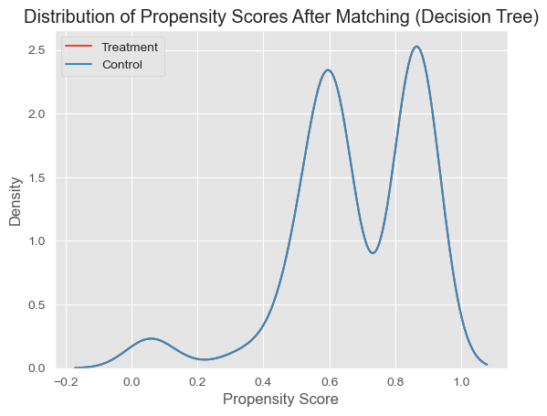

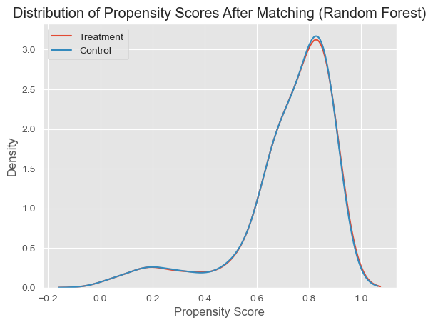

```python
# Reset index of matched_control_df
matched_control_tree_df = matched_control_tree_df.reset_index(drop=True)

# Plot the distribution of propensity scores after matching
sns.kdeplot(treatment_pscore_tree_df['pscore_tree'], label='Treatment')
sns.kdeplot(matched_control_tree_df['pscore_tree'], label='Control')
plt.title('Distribution of Propensity Scores After Matching (Decision Tree)')
plt.xlabel('Propensity Score')
plt.ylabel('Density')
plt.legend()
plt.show()


# Reset index of matched_control_df
matched_control_forest_df = matched_control_forest_df.reset_index(drop=True)

# Plot the distribution of propensity scores after matching
sns.kdeplot(treatment_pscore_forest_df['pscore_forest'], label='Treatment')
sns.kdeplot(matched_control_forest_df['pscore_forest'], label='Control')
plt.title('Distribution of Propensity Scores After Matching (Random Forest)')
plt.xlabel('Propensity Score')
plt.ylabel('Density')
plt.legend()
plt.show()
```

```python
# Compute mean and variance of each covariate for treatment and control groups after matching
means_treatment_matched_tree = treatment_pscore_tree_df.drop(columns=['treat', 'pscore_logit', 'black', 'hispan', 'married', 'nodegree', 'pscore_tree', 'pscore_forest']).mean()
means_control_matched_tree = matched_control_tree_df.drop(columns=['treat', 'pscore_logit', 'black', 'hispan', 'married', 'nodegree', 'pscore_tree', 'pscore_forest']).mean()
variances_treatment_before_tree = treatment_pscore_tree_df.drop(columns=['treat', 'pscore_logit', 'black', 'hispan', 'married', 'nodegree', 'pscore_tree', 'pscore_forest']).var()
variances_control_before_tree = matched_control_tree_df.drop(columns=['treat', 'pscore_logit', 'black', 'hispan', 'married', 'nodegree', 'pscore_tree', 'pscore_forest']).var()

# Compute absolute standardized differences in means for each covariate
ASMDs_tree = abs(means_treatment_matched_tree - means_control_matched_tree) / ((variances_treatment_before_tree + variances_control_before_tree)/2)**0.5

# Print absolute standardized differences in means for each covariate
print("Absolute Standardized Differences in Means (ASMDs) after matching (Decision Trees):")
print(ASMDs_tree)
```

```
Absolute Standardized Differences in Means (ASMDs) after matching (Decision Trees):
age     0.471801
educ    1.241047
re74    0.023672
re75    0.424546
re78    0.696978
dtype: float64
```

```python
# Compute mean and variance of each covariate for treatment and control groups after matching
means_treatment_matched_forest = treatment_pscore_forest_df.drop(columns=['treat', 'pscore_logit', 'black', 'hispan', 'married', 'nodegree', 'pscore_tree', 'pscore_forest']).mean()
means_control_matched_forest = matched_control_forest_df.drop(columns=['treat', 'pscore_logit', 'black', 'hispan', 'married', 'nodegree', 'pscore_tree', 'pscore_forest']).mean()
variances_treatment_before_forest = treatment_pscore_forest_df.drop(columns=['treat', 'pscore_logit', 'black', 'hispan', 'married', 'nodegree', 'pscore_tree', 'pscore_forest']).var()
variances_control_before_forest = matched_control_forest_df.drop(columns=['treat', 'pscore_logit', 'black', 'hispan', 'married', 'nodegree', 'pscore_tree', 'pscore_forest']).var()

# Compute absolute standardized differences in means for each covariate
ASMDs_forest = abs(means_treatment_matched_forest - means_control_matched_forest) / ((variances_treatment_before_forest + variances_control_before_forest)/2)**0.5

# Print absolute standardized differences in means for each covariate
print("Absolute Standardized Differences in Means (ASMDs) after matching (Random Forest):")
print(ASMDs_forest)
```

```
Absolute Standardized Differences in Means (ASMDs) after matching (Random Forest):
age     0.228691
educ    0.042984
re74    0.270011
re75    0.436783
re78    0.129233
dtype: float64
```

```python
# Calculate the average effect of treatment on wages (re78) after matching
average_effect_tree = treatment_pscore_tree_df['re78'].mean() - matched_control_tree_df['re78'].mean()

# Print the average effect of treatment on wages
print("Average effect of treatment on wages after matching (Decision Tree):", average_effect_tree)
```

```
Average effect of treatment on wages after matching (Decision Tree): -4652.652253513518
```

```python
# Calculate the average effect of treatment on wages (re78) after matching
average_effect_forest = treatment_pscore_forest_df['re78'].mean() - matched_control_forest_df['re78'].mean()

# Print the average effect of treatment on wages
print("Average effect of treatment on wages after matching (Random Forest):", average_effect_forest)
```

```
Average effect of treatment on wages after matching (Random Forest): 860.0761379459464
```

#### 8.7

Why do you think the decision tree regressor performed badly on balancing the covariates of the treat and control groups?

**Hint:** Look at the distances of the ten nearest neighbors output by `.kneighbors()` for the propensity scores of the decision tree model. What do you see? Why do you think these distances may have an impact on balancing?

**Answer.**

```python
from sklearn.neighbors import NearestNeighbors

# Fit a Nearest Neighbors model to the propensity scores
nn_model = NearestNeighbors(n_neighbors=10)
nn_model.fit(pscore_tree.reshape(-1, 1))  # Reshape to match expected input format

# Get the indices of the ten nearest neighbors for each individual's propensity score
distances, indices = nn_model.kneighbors(pscore_tree.reshape(-1, 1))

# Print the indices of nearest neighbors for the first individual
print("Indices of nearest neighbors for the first individual:")
print(indices[0])

# Print the distances to the nearest neighbors for the first individual
print("Distances to nearest neighbors for the first individual:")
print(distances[0])
```

```
Indices of nearest neighbors for the first individual:
[ 4 13  6 11  3  5  7  0  2  8]
Distances to nearest neighbors for the first individual:
[0. 0. 0. 0. 0. 0. 0. 0. 0. 0.]
```